# Generovanie procesov

Vo všeobecnom prístupe pri modelovaní ČR sú 2 dôležité etapy:

1. práca s trendom, sezónnosťou (ich odstránenie)
2. práca so stacionárnym zvyškom - reziduami (nájdenie modelu pre reziduá)

Odstraňovanie trendu:

- lineárna regresia
- diferencovaním
- vyrovnávanie
  - kĺzavými priemermi,
  - odstránením vyších frekvencií (Fourierova analýza)
  - exponenciálne vyrovnávanie

Odstraňovanie trendu a sezónnosti:

- harmonická regresia (Fourierova analýza - periodickosť sa modeluje funkciami sin, cos)
- diferencovaním s oneskorením d, kde d je perióda sezónnej zložky
- vyrovnávanie kĺzavými priemermi

Budeme striedať úlohy na obe etapy.

### Binárny proces

#### Definícia

**Binárnym procesom** nazývame ČR $\{X_t, t=1,2,3...\}$, ktorého zložky sú nezávislé náhodné premenné s rozdelením pravdepodobnosti $P(X_t=1)=p; \quad P(X_t=-1)=1-p$

#### Generovanie v R

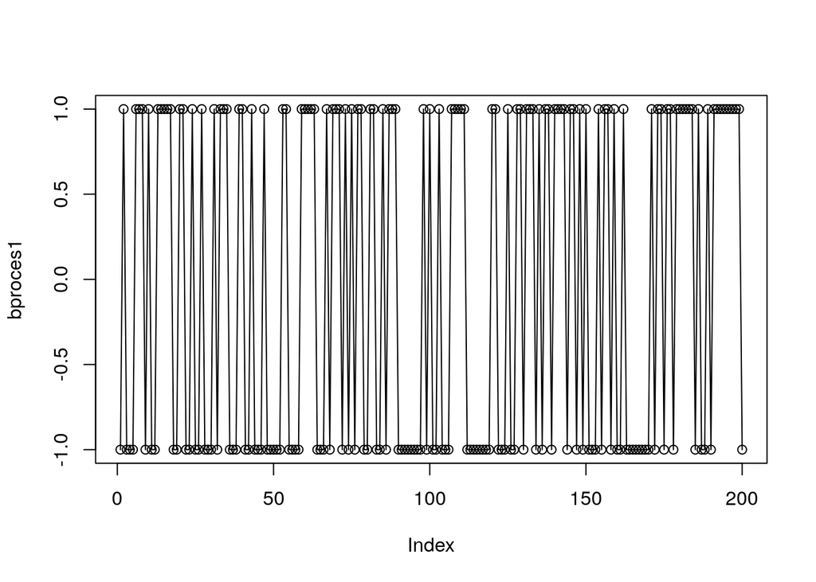

```r
n<-200
p<-0.5

for(i in 1:1){
  bproces1<-2*rbinom(n,1,p)-1
  #bproces1<-rbinom(n,1,p) # vytvorenie binarneho procesu
  bproces1

  # Generovanie nahodnej prechadzky
  #randomWalk <- cumsum(bproces1)
  #plot(randomWalk)
  plot(bproces1, type='o')
}
```

#### Intuitívne pozorovanie

Binárny proces

- bez trendu
- nulová stredná hodnota
- konštantná variabilita
- vieme konštatovať -> je to stacionárny rad

#### Reálne príklady

- párne/nepárne hody kockou
- hodenie 6-tky na kocke pre p=1/6
- narodenie chlapcov/dievčat
- realizácie úspešnosti trestných hodov hráčov NBA p=.77

Nestáva sa, že by po sebe nasledovalo veľa rovnakých hodnôt. Na základe predchádzajúcich hodnôt nevieme odhadnúť ďalšie, pretože zložky ČR sú nezávislé.

**Úloha**

Dokážte, že binárny proces je stacionárny.

Stacionarita radu:

- stredná hodnota $\mu_t$ je konštantná
- kovariancia $\gamma(t+h,t) = \gamma(h)$ nezávisí od času

Konštantnosť strednej hodnoty: $\mu(X) = E(X_t) = \sum_{k=\pm 1}p_kx_k = p\cdot 1 +(1-p)(-1) = 2p-1$ Tá nezávisí od času, takže podmienka je splnená.

$\gamma(t+h,t) = Cov(X_{t+h}, X_t) = E(X_{t+h}X_t) -E(X_{t+h})E(X_t) = 0$ lebo máme nezávislosť a platí $E(X_{t+h}X_t) = E(X_{t+h})E(X_t)$.

Výpočet druhého momentu: $E(X_t^2) = \sum_{k=\pm 1}x_k^2p_k$

$h = 0$: $\gamma(t,t)=D(X_t)=E(X_{t}^2) - E(X_{t})^2 = p+(1-p)-(2p-1)^2=1-4p^2+4p-1=4p(1-p)$

Záver: $\gamma = 4p(1-p)\delta_{k,0}$

### IID proces

#### Definícia

**IID procesom** nazývame ČR $\{X_t, t=1,2,3...\}$, ktorého zložky sú nezávislé a rovnako rozdelené.

IID je špeciálny prípad bieleho šumu. Binárny proces je špeciálny prípad IID procesu. Ak je IID zo spojitého rozdelenia, takho nazývame aj *šum*.

#### Generovanie IID~N(0,1) v R

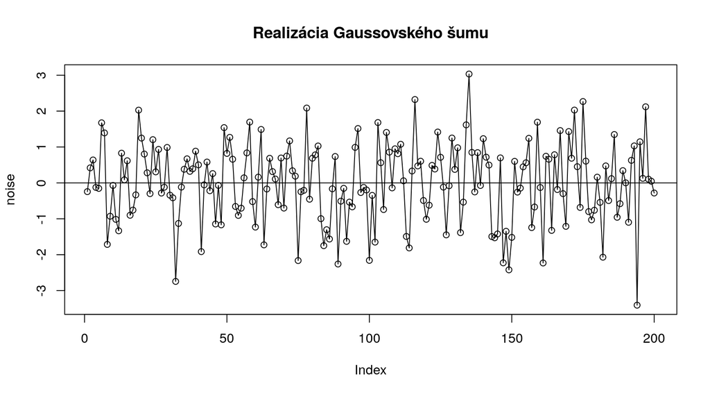

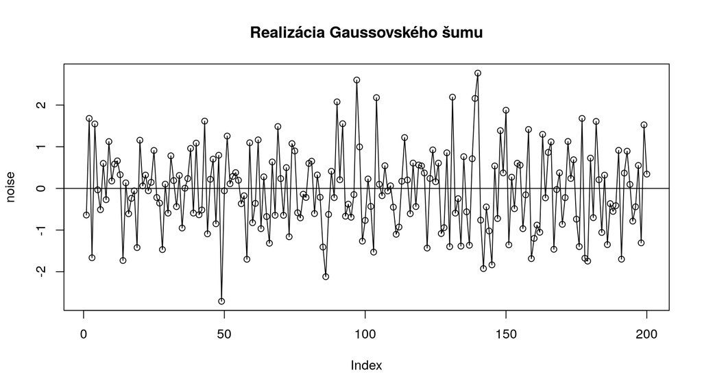

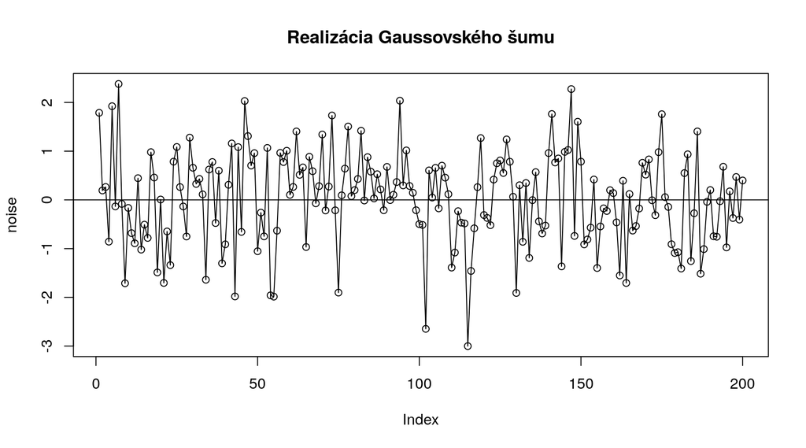

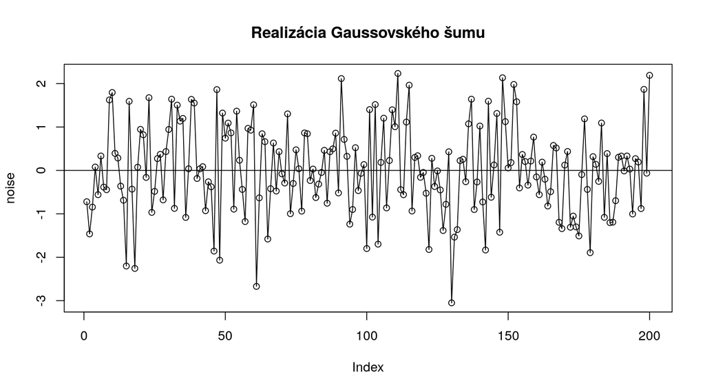

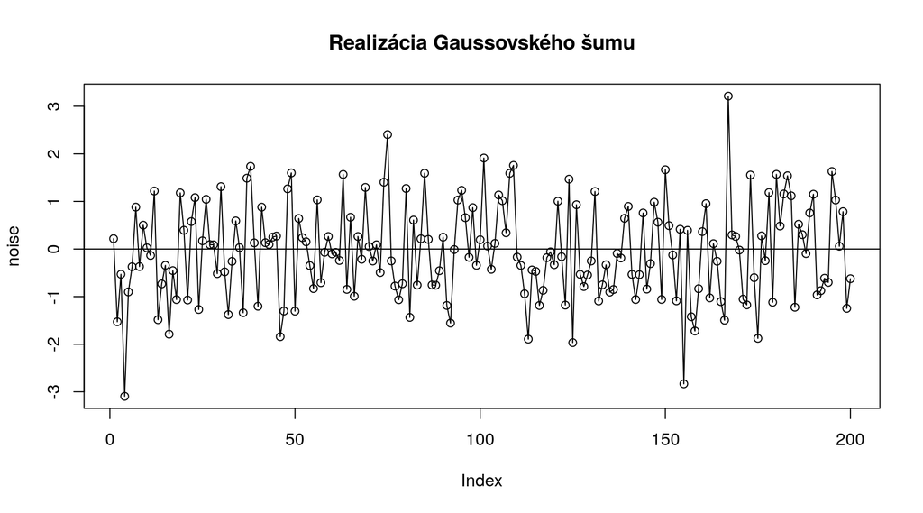

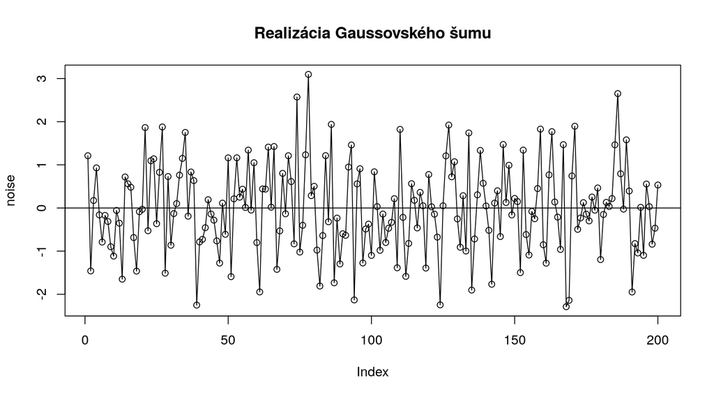

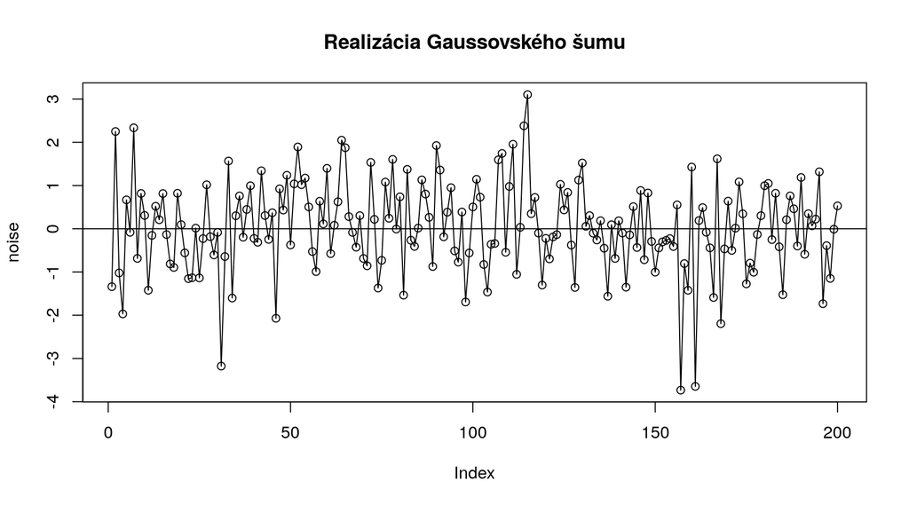

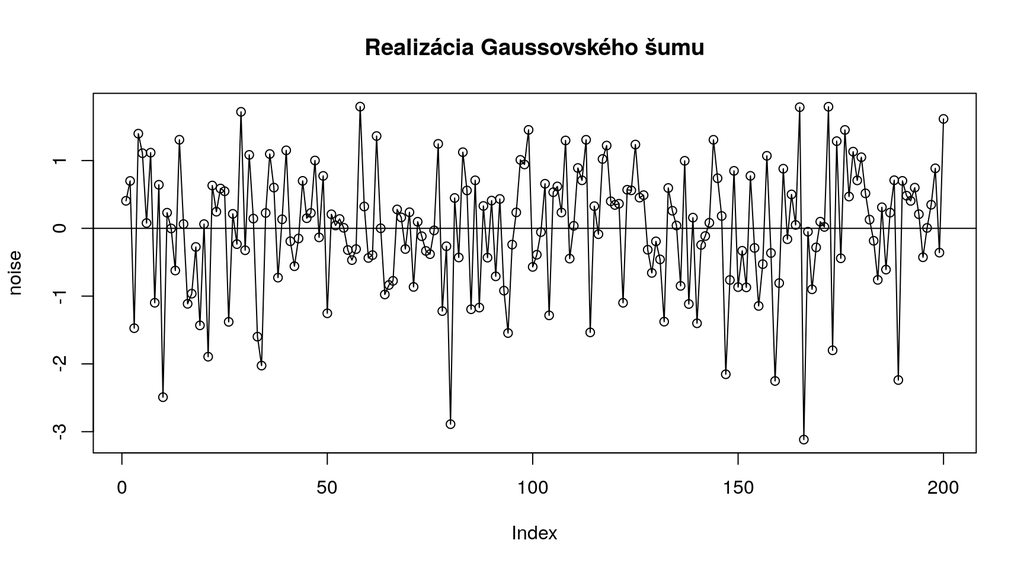

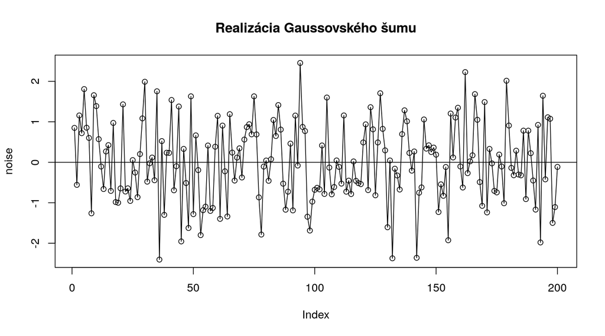

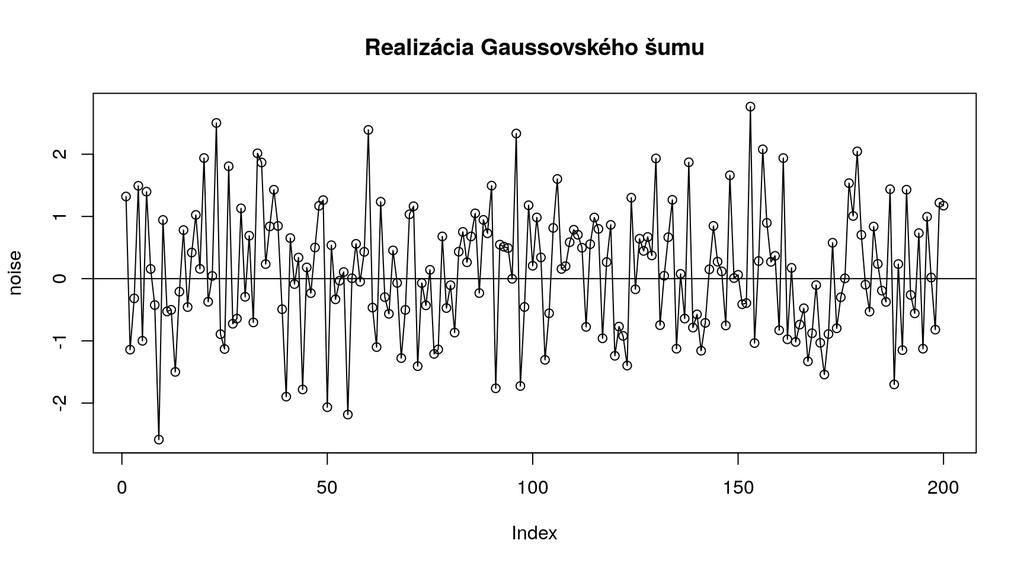

```r
n<-200
for(i in 1:10){
  noise<-rnorm(n,0,1)
  plot(noise, type = "o", main="Realizácia Gaussovského šumu")
  abline(0,0)
}
```

Vygenerovať niekoľko takýchto realizácii a sledovať, či sú prítomné dlhšie sekvencie hodnôt s rovnakým znamienkom.

#### Intuitívne pozorovanie

- bez trendu
- stredná hodnota je nulová
- konštantná disperzia
- ide o stacionárny ČR

## Zadanie

Chceme 98 náhodných hodnôt náhodného bieleho šumu a porovnať ich s reziduami z príkladu s Hurónskym jazerom.

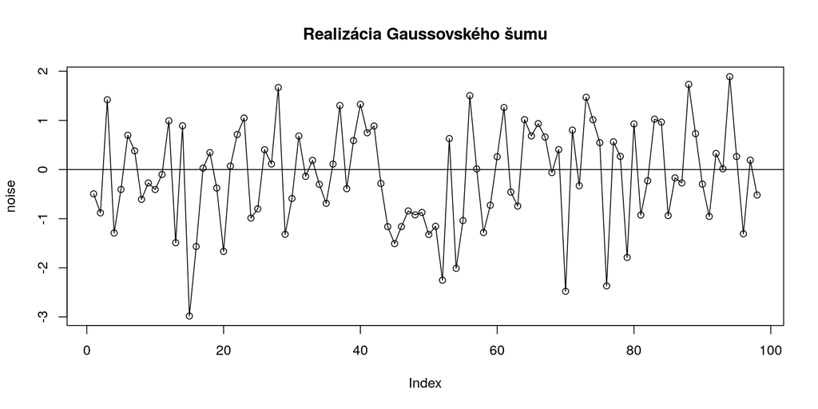

```r
n<-98
noise<-rnorm(n,0,1)
plot(noise, type = "o", main="Realizácia Gaussovského šumu")
abline(0,0)
```

Vloženie obrázku z rovnakého priečinku:

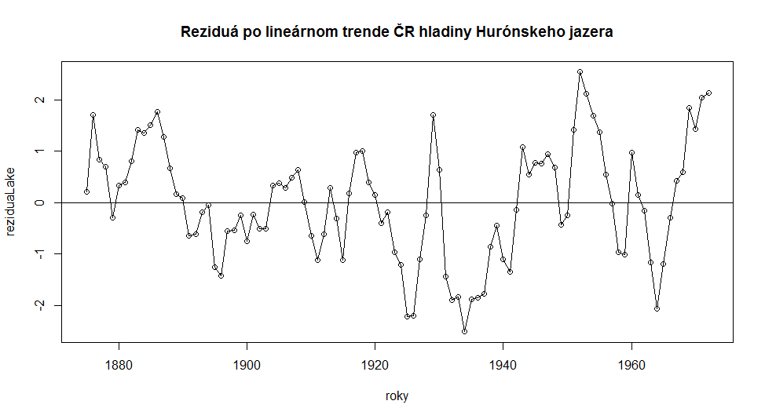

#### Komentár

Môžeme prehlásiť reziduá ČR Hurónskeho jazera za biely šum? Na základe grafu povieme, že nie. V prípade Hurónskeho jazera pozorujeme typickú situáciu pre hodnoty reziuí ČR:

- absencia badateľného trendu
- ustálenosť/stacionarita
- plynulosť/hladkosť grafun netypická pre IID/white noise
- pozorujeme príliš dlhé sekvencie residuí s rovnakým znamienkom, čo naznačuje skorelovanosť dát
- kým po pozorovanej hodnote IID môže nasledovať aj záporná aj kladná aj takmer nulová hodnota s rovnakou pravdepodobnosťou, pre reálne dáta bude pravdepodobná blízka hodnota

*Výhoda korelácie dát:* vieme lepšie predikovať budúce hodnoty ČR. Žiaľ, známe metódy môžeme defenestrovať, keďže predpokladajú nekorelované dáta… Budeme musieť rozšíriť náš aparát o nové postupy.